# Sample Size Estimation for Familiarity Norming

Erin M. Buchanan

2026-08-26

```r
label_by_target <- function(power_tbl, group_vars = "run_id", power_levels = REFINE_POWER_LEVELS) {
  power_tbl %>%
    dplyr::group_by(dplyr::across(dplyr::all_of(group_vars))) %>%
    dplyr::mutate(target_power = power_levels[((dplyr::row_number() - 1) %% length(power_levels)) + 1]) %>%
    dplyr::ungroup()
}

summarize_by_target <- function(power_tbl, group_vars = "run_id", power_levels = REFINE_POWER_LEVELS) {
  label_by_target(power_tbl, group_vars, power_levels) %>%
    dplyr::group_by(target_power) %>%
    dplyr::summarise(
      n_runs = sum(!is.na(corrected_sample_size)),
      mean_recommended_sample_size = mean(corrected_sample_size, na.rm = TRUE),
      median_recommended_sample_size = median(corrected_sample_size, na.rm = TRUE),
      sd_recommended_sample_size = sd(corrected_sample_size, na.rm = TRUE),
      min_recommended_sample_size = min(corrected_sample_size, na.rm = TRUE),
      max_recommended_sample_size = max(corrected_sample_size, na.rm = TRUE),
      .groups = "drop"
    ) %>%
    dplyr::arrange(target_power) %>%
    dplyr::mutate(recommended_sample_size = ceiling(cummax(median_recommended_sample_size)))
}

# Standard 1.5x IQR rule. Applied separately to the precision-recommended
# and reliability-recommended sample sizes for a group, so a handful of
# very small/noisy source datasets (which can swing corrected_sample_size
# or the reliability-hit sample size wildly) don't dominate the average.
IQR_MULTIPLIER <- 1.5

iqr_bounds <- function(x, multiplier = IQR_MULTIPLIER) {
  x <- x[is.finite(x)]
  if (length(x) < 4) return(c(lower = -Inf, upper = Inf))
  qs <- stats::quantile(x, probs = c(0.25, 0.75), na.rm = TRUE, type = 7)
  iqr <- qs[[2]] - qs[[1]]
  c(lower = qs[[1]] - multiplier * iqr, upper = qs[[2]] + multiplier * iqr)
}

n_at_precision_per_run <- function(power_tbl, group_vars = "run_id", target_power = TARGET_POWER) {
  label_by_target(power_tbl, group_vars) %>%
    dplyr::filter(target_power == !!target_power) %>%
    dplyr::transmute(run_id, n_precision = corrected_sample_size)
}

# Reliability is never estimated below n = 20 (see run_simulation_pipeline() /
# run_simulation_pipeline_chunked() in functions.R), so the sample size at
# which a run first hits the reliability target is naturally floored at 20 -
# even a dataset that happens to hit 80% reliability at very small n can't
# pull this metric below the floor.
n_at_reliability_per_run <- function(rel_tbl, target_reliability = TARGET_RELIABILITY) {
  rel_tbl %>%
    dplyr::mutate(
      reliability_m = as.numeric(reliability_m),
      sample_size = as.numeric(sample_size)
    ) %>%
    dplyr::filter(is.finite(reliability_m)) %>%
    dplyr::group_by(run_id) %>%
    dplyr::filter(reliability_m >= target_reliability) %>%
    dplyr::arrange(sample_size) %>%
    dplyr::slice_head(n = 1) %>%
    dplyr::ungroup() %>%
    dplyr::transmute(run_id, n_reliability = sample_size)
}

# For one group (Overall, a POS tag, or a length bucket): per-run n needed
# for target_power% precision and for target_reliability split-half
# reliability, IQR-outlier-trimmed separately, then averaged together into
# a single recommended sample size.
summarize_group_recommendation <- function(power_tbl, rel_tbl,
                                           target_power = TARGET_POWER,
                                           target_reliability = TARGET_RELIABILITY) {
  precision_per_run <- n_at_precision_per_run(power_tbl, target_power = target_power)
  reliability_per_run <- n_at_reliability_per_run(rel_tbl, target_reliability = target_reliability)

  precision_bounds <- iqr_bounds(precision_per_run$n_precision)
  reliability_bounds <- iqr_bounds(reliability_per_run$n_reliability)

  per_run <- precision_per_run %>%
    dplyr::full_join(reliability_per_run, by = "run_id") %>%
    dplyr::mutate(
      precision_outlier = is.finite(n_precision) &
        (n_precision < precision_bounds[["lower"]] | n_precision > precision_bounds[["upper"]]),
      reliability_outlier = is.finite(n_reliability) &
        (n_reliability < reliability_bounds[["lower"]] | n_reliability > reliability_bounds[["upper"]])
    )

  precision_clean <- per_run$n_precision[is.finite(per_run$n_precision) & !per_run$precision_outlier]
  reliability_clean <- per_run$n_reliability[is.finite(per_run$n_reliability) & !per_run$reliability_outlier]

  precision_median <- stats::median(precision_clean)
  reliability_median <- stats::median(reliability_clean)

  list(
    per_run = per_run,
    precision_n_total = nrow(precision_per_run),
    precision_n_kept = length(precision_clean),
    precision_median = precision_median,
    reliability_n_total = nrow(reliability_per_run),
    reliability_n_kept = length(reliability_clean),
    reliability_median = reliability_median,
    recommended_n = mean(c(precision_median, reliability_median))
  )
}

# Renders the table/plot/recommendation block for one group (Overall, a
# POS tag, or a length bucket) - shared by the Overall/POS/Length sections
# below so the reporting logic only has to be written once.
render_group_section <- function(label, power_tbl, rel_tbl, group_vars = "run_id") {
  n_runs <- dplyr::n_distinct(power_tbl$run_id)
  cat(sprintf("Based on %d dataset run(s).\n\n", n_runs))

  if (n_runs == 0) {
    cat("No data available for this group.\n\n---\n")
    return(invisible(NULL))
  }

  target_summary <- summarize_by_target(power_tbl, group_vars = group_vars)
  labeled_power <- label_by_target(power_tbl, group_vars = group_vars)

  cat("**Recommended sample size per item, by target precision (% of simulations hitting the AIPE cutoff):**\n\n")
  print(htmltools::tagList(DT::datatable(
    target_summary %>%
      dplyr::mutate(dplyr::across(where(is.numeric), ~ round(.x, 2))),
    rownames = FALSE, options = list(dom = "t", pageLength = 10)
  )))

  box_dat <- labeled_power %>%
    dplyr::mutate(target_power = factor(target_power, levels = REFINE_POWER_LEVELS))
  print(
    ggplot2::ggplot(box_dat, ggplot2::aes(x = target_power, y = corrected_sample_size)) +
      ggplot2::geom_boxplot(fill = "#d9e7ff", outlier.alpha = 0.2, width = 0.6) +
      ggplot2::geom_jitter(width = 0.12, alpha = 0.35, size = 1.4) +
      ggplot2::geom_line(
        data = target_summary %>% dplyr::mutate(target_power = factor(target_power, levels = REFINE_POWER_LEVELS)),
        ggplot2::aes(x = target_power, y = recommended_sample_size, group = 1),
        color = "#b00020", linewidth = 0.9
      ) +
      ggplot2::geom_point(
        data = target_summary %>% dplyr::mutate(target_power = factor(target_power, levels = REFINE_POWER_LEVELS)),
        ggplot2::aes(x = target_power, y = recommended_sample_size),
        color = "#b00020", size = 2.5
      ) +
      ggplot2::labs(
        x = "Target precision (%)", y = "Corrected sample size",
        title = paste0(label, ": spread of per-dataset recommendations"),
        subtitle = "red line = across-run running max of the median"
      ) +
      ggplot2::theme_minimal()
  )

  rec <- summarize_group_recommendation(power_tbl, rel_tbl)

  if (nrow(rel_tbl) > 0) {
    cat("\n\n**Reliability by sample size (median across runs):**\n\n")
    rel_curve <- rel_tbl %>%
      dplyr::mutate(sample_size = as.numeric(sample_size), reliability_m = as.numeric(reliability_m)) %>%
      dplyr::group_by(sample_size) %>%
      dplyr::summarise(median_reliability = median(reliability_m, na.rm = TRUE), .groups = "drop")

    print(
      ggplot2::ggplot(rel_curve, ggplot2::aes(x = sample_size, y = median_reliability)) +
        ggplot2::geom_point(alpha = 0.5, size = 1.8, color = "#1f4e79") +
        ggplot2::geom_hline(yintercept = TARGET_RELIABILITY, linetype = "dashed", color = "#b00020") +
        ggplot2::labs(
          x = "Sample size", y = "Median split-half reliability",
          title = paste0(label, ": reliability curve across dataset runs"),
          subtitle = sprintf("dashed line = %.0f%% target", TARGET_RELIABILITY * 100)
        ) +
        ggplot2::theme_minimal()
    )
  }

  cat(sprintf(
    "\n\n**Recommended n (%d%% precision + %d%% reliability, IQR-trimmed medians averaged): %.1f -> %d participants/item**\n\n",
    TARGET_POWER, TARGET_RELIABILITY * 100, rec$recommended_n, ceiling(rec$recommended_n)
  ))
  cat(sprintf(
    "- Precision: %.1f (median of %d/%d runs kept after IQR trim)\n",
    rec$precision_median, rec$precision_n_kept, rec$precision_n_total
  ))
  cat(sprintf(
    "- Reliability: %.1f (median of %d/%d runs kept after IQR trim)\n",
    rec$reliability_median, rec$reliability_n_kept, rec$reliability_n_total
  ))

  cat("\n\n**Per-dataset detail (n at target precision, n at target reliability, outlier flags):**\n\n")
  print(htmltools::tagList(DT::datatable(
    rec$per_run %>%
      dplyr::mutate(dplyr::across(c(n_precision, n_reliability), ~ round(.x, 1))) %>%
      dplyr::arrange(dplyr::desc(n_precision)),
    rownames = FALSE, options = list(pageLength = 10)
  )))

  cat("\n\n---\n")

  rec
}
```

## Target Criteria and Outlier Handling

We target 80% power (AIPE precision) and 80% split-half reliability, and report the recommended sample size as the average of those two numbers. Precision and reliability answer different questions about the same design (how accurately measured is the estimated mean vs. how consistent are the item scores), so averaging them gives one practical number rather than always taking the stricter of the two. Reliability is only ever estimated starting at *n* = 20 (see `functions.R`), so even a dataset that happens to reach the reliability target at a very small sample size cannot pull the recommended sample size below 20.

Each of these numbers is computed per dataset run (i.e., per source paper/corpus) before pooling: every dataset run contributes one “n needed for 80% precision” value and one “n needed for 80% reliability” value. A handful of source datasets are small, noisy, or otherwise unusual and can pull these per-run numbers to extreme highs or lows. Before pooling across runs, we drop outlier runs using the standard 1.5 x IQR rule (values more than 1.5 interquartile ranges below Q1 or above Q3 are dropped), applied separately to the precision values and the reliability values. We then take the median of the remaining runs for each metric (median rather than mean, since a handful of runs can still sit near the outlier boundary without being dropped outright - in practice the two are close once outliers are trimmed, but median is the more standard choice for a “typical” recommendation). The tables below show which runs were considered outliers.

## Loading Refined Results

```r
cat(sprintf(
  "Loaded refined output for **%d dataset run(s)**.\n\n",
  dplyr::n_distinct(refined_summary$overall_power$run_id)
))
```

Loaded refined output for **43 dataset run(s)**.

Each dataset contributes one simulation “run” (i.e., one row per source paper/corpus that reported familiarity for the words in our stimuli set). The results below pool across *all* dataset runs, since our own norming study will draw one sample of participants per item.

## Overall Results

```r
overall_rec <- render_group_section(
  "Overall",
  refined_summary$overall_power,
  refined_summary$overall_rel
)
```

Based on 43 dataset run(s).

**Recommended sample size per item, by target precision (% of simulations hitting the AIPE cutoff):**

| target_power | n_runs | mean_recommended_sample_size | median_recommended_sample_size | sd_recommended_sample_size | min_recommended_sample_size | max_recommended_sample_size | recommended_sample_size |
| --- | --- | --- | --- | --- | --- | --- | --- |
| 70 | 43 | 45.74 | 38.85 | 24.7 | 9.21 | 157.92 | 39 |
| 75 | 43 | 47.82 | 41.13 | 24.54 | 9.21 | 157.92 | 42 |
| 80 | 43 | 50.62 | 42.35 | 25.02 | 9.83 | 157.92 | 43 |
| 85 | 43 | 55.16 | 48.11 | 25.28 | 19.19 | 157.92 | 49 |
| 90 | 43 | 60.16 | 53.72 | 26.14 | 20.48 | 157.92 | 54 |
| 95 | 40 | 65.38 | 59.26 | 26.46 | 28.62 | 157.92 | 60 |

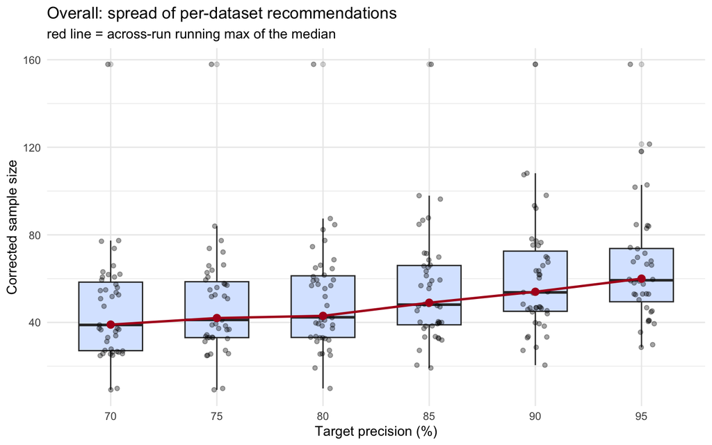

**Reliability by sample size (median across runs):**

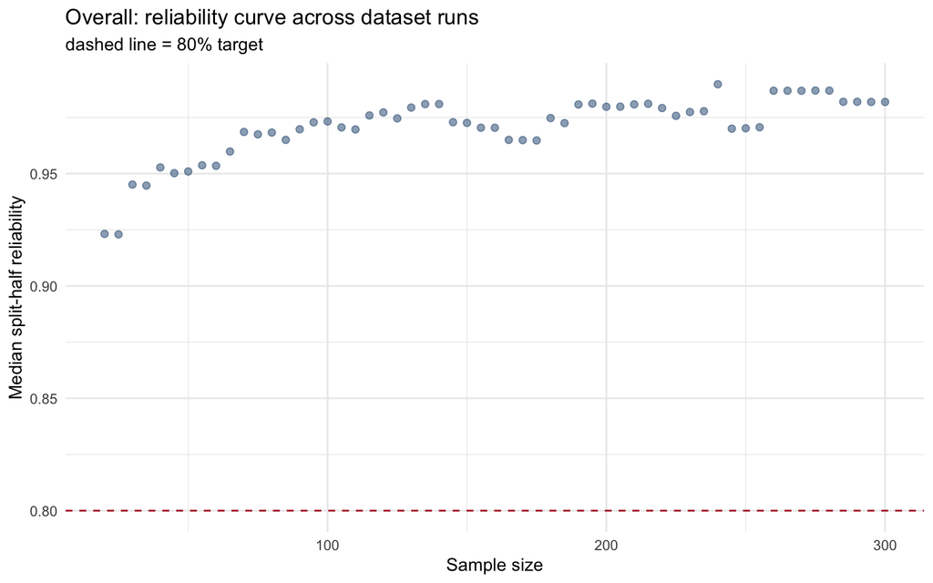

**Recommended n (80% precision + 80% reliability, IQR-trimmed medians averaged): 31.1 -> 32 participants/item**

- Precision: 42.3 (median of 42/43 runs kept after IQR trim)
- Reliability: 20.0 (median of 40/42 runs kept after IQR trim)

**Per-dataset detail (n at target precision, n at target reliability, outlier flags):**

| run_id | n_precision | n_reliability | precision_outlier | reliability_outlier |
| --- | --- | --- | --- | --- |
| janschewitz | 157.9 | 20 | True | False |
| barca | 87.5 | 20 | False | False |
| chedid | 84.6 | 20 | False | False |
| ballot | 82.4 | 20 | False | False |
| yao | 77.4 | 20 | False | False |
| kraljevic | 74.6 | 20 | False | False |
| desrochers10 | 68.6 | 20 | False | False |
| eilola_finnish | 66.1 | 20 | False | False |
| raslescu | 64.9 | 20 | False | False |
| desrochers | 64.6 | 45 | False | True |

[output cut: 33 more lines]

## Results by Part of Speech

```r
pos_groups <- sort(unique(refined_summary$pos_power$group))
pos_rec_by_group <- purrr::map(pos_groups, function(g) {
  cat(sprintf("\n### %s\n\n", g))
  render_group_section(
    paste0("POS: ", g),
    refined_summary$pos_power %>% dplyr::filter(group == g),
    refined_summary$pos_rel %>% dplyr::filter(group == g)
  )
}) %>% setNames(pos_groups)
```

### modifiers

Based on 34 dataset run(s).

**Recommended sample size per item, by target precision (% of simulations hitting the AIPE cutoff):**

| target_power | n_runs | mean_recommended_sample_size | median_recommended_sample_size | sd_recommended_sample_size | min_recommended_sample_size | max_recommended_sample_size | recommended_sample_size |
| --- | --- | --- | --- | --- | --- | --- | --- |
| 70 | 34 | 45.27 | 40.09 | 26.47 | 8.98 | 158.23 | 41 |
| 75 | 34 | 47.06 | 41.97 | 26.08 | 8.98 | 158.23 | 42 |
| 80 | 34 | 49.55 | 46.73 | 25.99 | 9.87 | 158.23 | 47 |
| 85 | 33 | 52.91 | 47.27 | 25.65 | 19.27 | 158.23 | 48 |
| 90 | 33 | 56.24 | 51.4 | 26.55 | 19.27 | 158.23 | 52 |
| 95 | 28 | 60.48 | 55.25 | 26.03 | 27.73 | 158.23 | 56 |

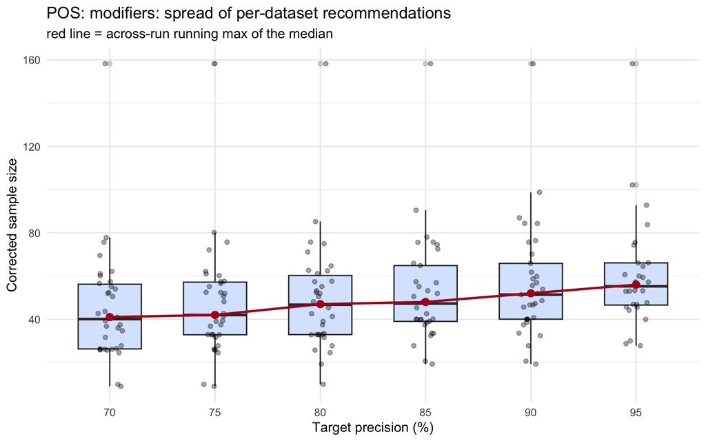

**Reliability by sample size (median across runs):**

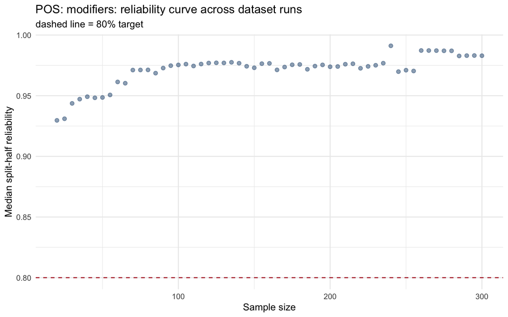

**Recommended n (80% precision + 80% reliability, IQR-trimmed medians averaged): 32.7 -> 33 participants/item**

- Precision: 45.3 (median of 33/34 runs kept after IQR trim)
- Reliability: 20.0 (median of 32/34 runs kept after IQR trim)

**Per-dataset detail (n at target precision, n at target reliability, outlier flags):**

| run_id | n_precision | n_reliability | precision_outlier | reliability_outlier |
| --- | --- | --- | --- | --- |
| janschewitz | 158.2 | 20 | True | False |
| ballot | 85.2 | 20 | False | False |
| barca | 75.7 | 20 | False | False |
| desrochers10 | 75 | 20 | False | False |
| chedid | 71.1 | 20 | False | False |
| desrochers | 64.7 | 25 | False | True |
| su | 62.6 | 20 | False | False |
| raslescu | 62.4 | 20 | False | False |
| kraljevic | 61.1 | 20 | False | False |
| morrow_young | 57.6 | 20 | False | False |

[output cut: 25 more lines]

### noun

Based on 43 dataset run(s).

**Recommended sample size per item, by target precision (% of simulations hitting the AIPE cutoff):**

| target_power | n_runs | mean_recommended_sample_size | median_recommended_sample_size | sd_recommended_sample_size | min_recommended_sample_size | max_recommended_sample_size | recommended_sample_size |
| --- | --- | --- | --- | --- | --- | --- | --- |
| 70 | 43 | 45.64 | 39.47 | 24.92 | 9.67 | 158.1 | 40 |
| 75 | 43 | 48.48 | 42.1 | 24.23 | 9.87 | 158.1 | 43 |
| 80 | 43 | 50.55 | 42.44 | 25.24 | 9.87 | 158.1 | 43 |
| 85 | 43 | 54.69 | 48.04 | 25.44 | 19.07 | 158.1 | 49 |
| 90 | 42 | 58.71 | 52.74 | 24.08 | 27.24 | 158.1 | 53 |
| 95 | 37 | 63.22 | 58.96 | 23.78 | 34.2 | 158.1 | 59 |

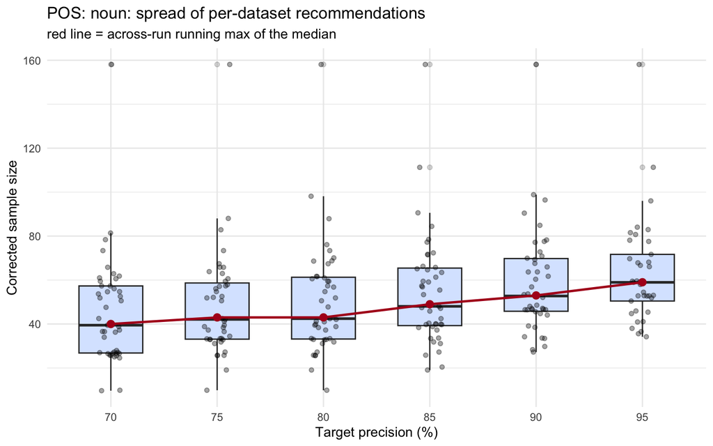

**Reliability by sample size (median across runs):**

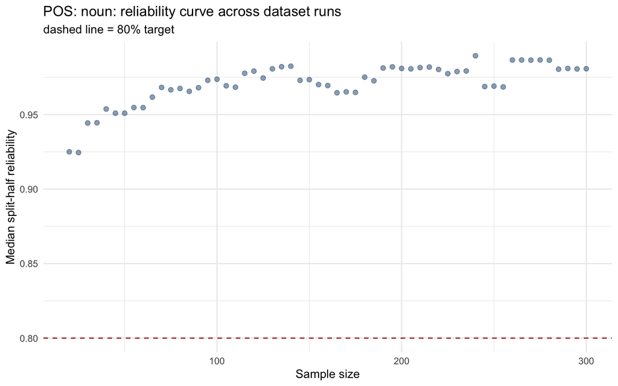

**Recommended n (80% precision + 80% reliability, IQR-trimmed medians averaged): 31.1 -> 32 participants/item**

- Precision: 42.3 (median of 42/43 runs kept after IQR trim)
- Reliability: 20.0 (median of 40/42 runs kept after IQR trim)

**Per-dataset detail (n at target precision, n at target reliability, outlier flags):**

| run_id | n_precision | n_reliability | precision_outlier | reliability_outlier |
| --- | --- | --- | --- | --- |
| janschewitz | 158.1 | 20 | True | False |
| barca | 98.1 | 20 | False | False |
| ballot | 87.9 | 20 | False | False |
| chedid | 76.1 | 20 | False | False |
| yao | 73.4 | 20 | False | False |
| kraljevic | 70.1 | 20 | False | False |
| eilola_finnish | 68.8 | 20 | False | False |
| desrochers10 | 68.6 | 20 | False | False |
| raslescu | 67.4 | 20 | False | False |
| morrow_young | 61.7 | 20 | False | False |

[output cut: 33 more lines]

### other

Based on 24 dataset run(s).

**Recommended sample size per item, by target precision (% of simulations hitting the AIPE cutoff):**

| target_power | n_runs | mean_recommended_sample_size | median_recommended_sample_size | sd_recommended_sample_size | min_recommended_sample_size | max_recommended_sample_size | recommended_sample_size |
| --- | --- | --- | --- | --- | --- | --- | --- |
| 70 | 24 | 45.04 | 38.08 | 30.48 | 9.35 | 157.88 | 39 |
| 75 | 24 | 46.51 | 38.08 | 31.16 | 9.35 | 157.88 | 39 |
| 80 | 24 | 49.01 | 38.08 | 31.36 | 19.42 | 157.88 | 39 |
| 85 | 24 | 53.54 | 38.08 | 31.45 | 19.42 | 157.88 | 39 |
| 90 | 22 | 56.27 | 40.28 | 33.03 | 24.21 | 157.88 | 41 |
| 95 | 17 | 54.96 | 42.46 | 31.56 | 29.83 | 157.88 | 43 |

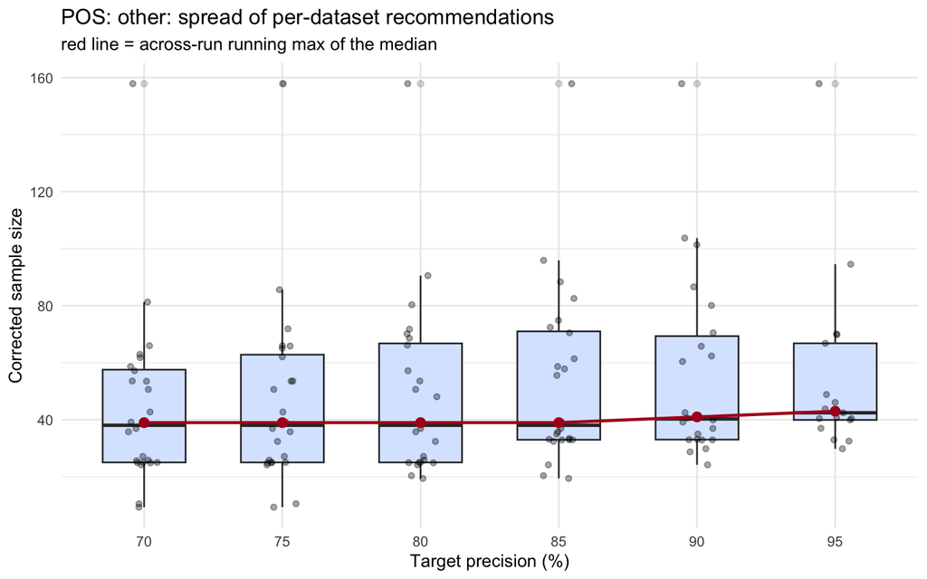

**Reliability by sample size (median across runs):**

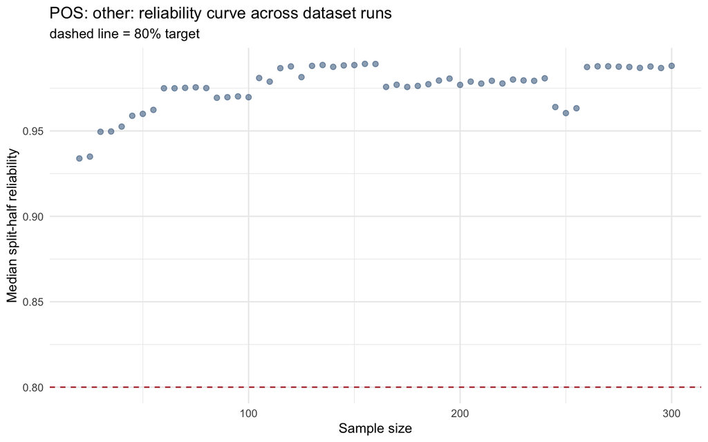

**Recommended n (80% precision + 80% reliability, IQR-trimmed medians averaged): 28.5 -> 29 participants/item**

- Precision: 37.0 (median of 23/24 runs kept after IQR trim)
- Reliability: 20.0 (median of 23/24 runs kept after IQR trim)

**Per-dataset detail (n at target precision, n at target reliability, outlier flags):**

| run_id | n_precision | n_reliability | precision_outlier | reliability_outlier |
| --- | --- | --- | --- | --- |
| janschewitz | 157.9 | 20 | True | False |
| ballot | 90.6 | 20 | False | False |
| chedid | 80.4 | 20 | False | False |
| desrochers10 | 71.8 | 20 | False | False |
| kraljevic | 70.1 | 20 | False | False |
| desrochers | 68.6 | 20 | False | False |
| gilhooly | 66.2 | 20 | False | False |
| morrow_old | 57.2 | 20 | False | False |
| morrow_young | 53.6 | 20 | False | False |
| soares | 50.7 | 20 | False | False |

[output cut: 14 more lines]

### verb

Based on 32 dataset run(s).

**Recommended sample size per item, by target precision (% of simulations hitting the AIPE cutoff):**

| target_power | n_runs | mean_recommended_sample_size | median_recommended_sample_size | sd_recommended_sample_size | min_recommended_sample_size | max_recommended_sample_size | recommended_sample_size |
| --- | --- | --- | --- | --- | --- | --- | --- |
| 70 | 32 | 45.32 | 36.79 | 27.92 | 9.06 | 158.15 | 37 |
| 75 | 32 | 46.65 | 39.45 | 27.91 | 9.06 | 158.15 | 40 |
| 80 | 31 | 47.28 | 40.14 | 27.43 | 9.79 | 158.15 | 41 |
| 85 | 31 | 51.05 | 43.73 | 27.28 | 9.79 | 158.15 | 44 |
| 90 | 31 | 55.48 | 47.1 | 27.25 | 19.34 | 158.15 | 48 |
| 95 | 27 | 64.37 | 58.01 | 28.63 | 28.78 | 158.15 | 59 |

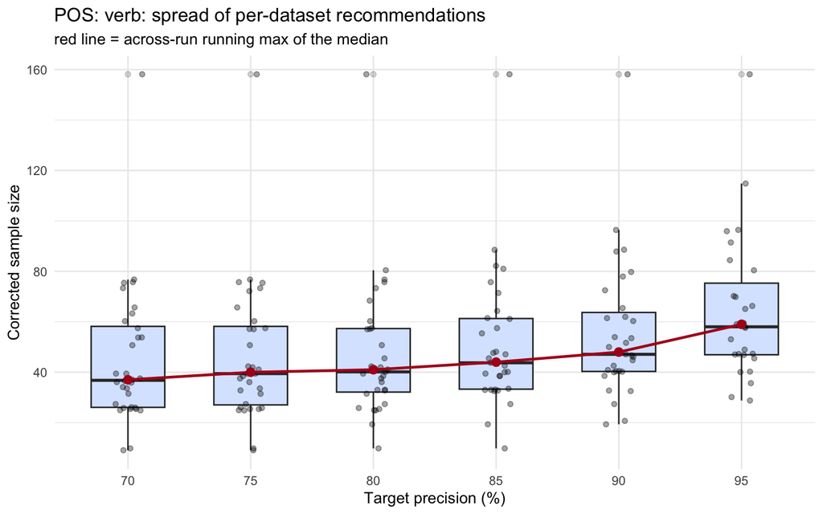

**Reliability by sample size (median across runs):**

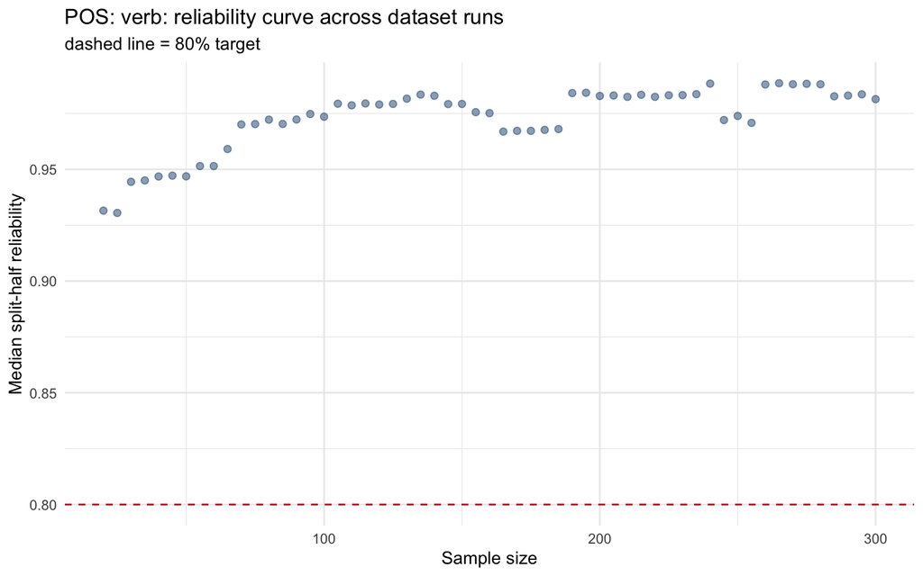

**Recommended n (80% precision + 80% reliability, IQR-trimmed medians averaged): 29.9 -> 30 participants/item**

- Precision: 39.8 (median of 30/31 runs kept after IQR trim)
- Reliability: 20.0 (median of 30/32 runs kept after IQR trim)

**Per-dataset detail (n at target precision, n at target reliability, outlier flags):**

| run_id | n_precision | n_reliability | precision_outlier | reliability_outlier |
| --- | --- | --- | --- | --- |
| janschewitz | 158.1 | 20 | True | False |
| chedid | 80.4 | 20 | False | False |
| ballot | 76.8 | 20 | False | False |
| barca | 75.7 | 20 | False | False |
| yao | 73.4 | 20 | False | False |
| desrochers10 | 68.4 | 20 | False | False |
| desrochers | 60.3 | 20 | False | False |
| sianipar | 57.5 | 80 | False | True |
| morrow_young | 57.2 | 20 | False | False |
| morrow_old | 57.1 | 20 | False | False |

[output cut: 23 more lines]

## Results by Word Length

```r
length_levels <- c("3", "4", "5", "6", "7", "8", "9", "10", "11+")
length_groups <- length_levels[length_levels %in% unique(refined_summary$length_power$group)]

length_rec_by_group <- purrr::map(length_groups, function(g) {
  cat(sprintf("\n### %s letters\n\n", g))
  render_group_section(
    paste0("Length: ", g),
    refined_summary$length_power %>% dplyr::filter(group == g),
    refined_summary$length_rel %>% dplyr::filter(group == g)
  )
}) %>% setNames(length_groups)
```

### 3 letters

Based on 20 dataset run(s).

**Recommended sample size per item, by target precision (% of simulations hitting the AIPE cutoff):**

| target_power | n_runs | mean_recommended_sample_size | median_recommended_sample_size | sd_recommended_sample_size | min_recommended_sample_size | max_recommended_sample_size | recommended_sample_size |
| --- | --- | --- | --- | --- | --- | --- | --- |
| 70 | 20 | 50.07 | 54.19 | 31.04 | 9.82 | 157.49 | 55 |
| 75 | 20 | 53.27 | 58.29 | 30.69 | 9.82 | 157.49 | 59 |
| 80 | 20 | 55.17 | 58.39 | 31.83 | 9.82 | 157.49 | 59 |
| 85 | 20 | 58.8 | 60.27 | 31.74 | 9.82 | 157.49 | 61 |
| 90 | 19 | 62.99 | 57.04 | 32.25 | 20.62 | 157.49 | 61 |
| 95 | 15 | 64.16 | 59.44 | 31.72 | 30.14 | 157.49 | 61 |

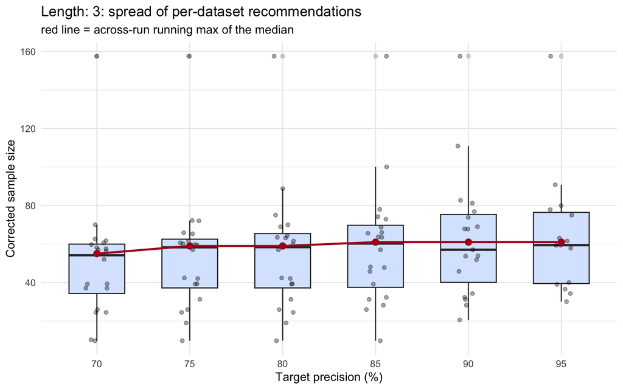

**Reliability by sample size (median across runs):**

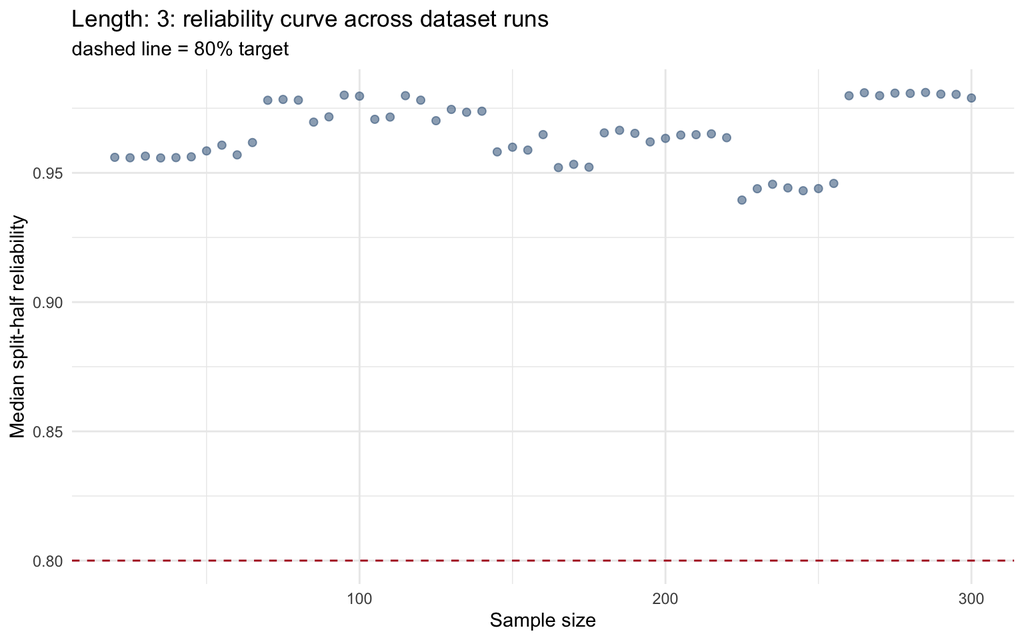

**Recommended n (80% precision + 80% reliability, IQR-trimmed medians averaged): 38.5 -> 39 participants/item**

- Precision: 57.0 (median of 19/20 runs kept after IQR trim)
- Reliability: 20.0 (median of 20/20 runs kept after IQR trim)

**Per-dataset detail (n at target precision, n at target reliability, outlier flags):**

| run_id | n_precision | n_reliability | precision_outlier | reliability_outlier |
| --- | --- | --- | --- | --- |
| janschewitz | 157.5 | 20 | True | False |
| chedid | 88.8 | 20 | False | False |
| desrochers10 | 75 | 20 | False | False |
| kraljevic | 69.9 | 20 | False | False |
| morrow_old | 69 | 20 | False | False |
| soares | 64.3 | 20 | False | False |
| mahjou | 63.5 | 20 | False | False |
| eilola_finnish | 63.2 | 20 | False | False |
| morrow_young | 61.6 | 20 | False | False |
| desrochers | 59.7 | 20 | False | False |

[output cut: 10 more lines]

### 4 letters

Based on 37 dataset run(s).

**Recommended sample size per item, by target precision (% of simulations hitting the AIPE cutoff):**

| target_power | n_runs | mean_recommended_sample_size | median_recommended_sample_size | sd_recommended_sample_size | min_recommended_sample_size | max_recommended_sample_size | recommended_sample_size |
| --- | --- | --- | --- | --- | --- | --- | --- |
| 70 | 37 | 49.61 | 42.31 | 28.37 | 9.92 | 157.6 | 43 |
| 75 | 37 | 51.82 | 42.45 | 28.64 | 9.92 | 157.6 | 43 |
| 80 | 36 | 52.36 | 46.46 | 26.24 | 9.92 | 157.6 | 47 |
| 85 | 35 | 55.23 | 48.35 | 26.09 | 20.5 | 157.6 | 49 |
| 90 | 33 | 57.3 | 52.78 | 26.29 | 20.5 | 157.6 | 53 |
| 95 | 22 | 62.64 | 56.17 | 29.58 | 29.93 | 163.04 | 57 |

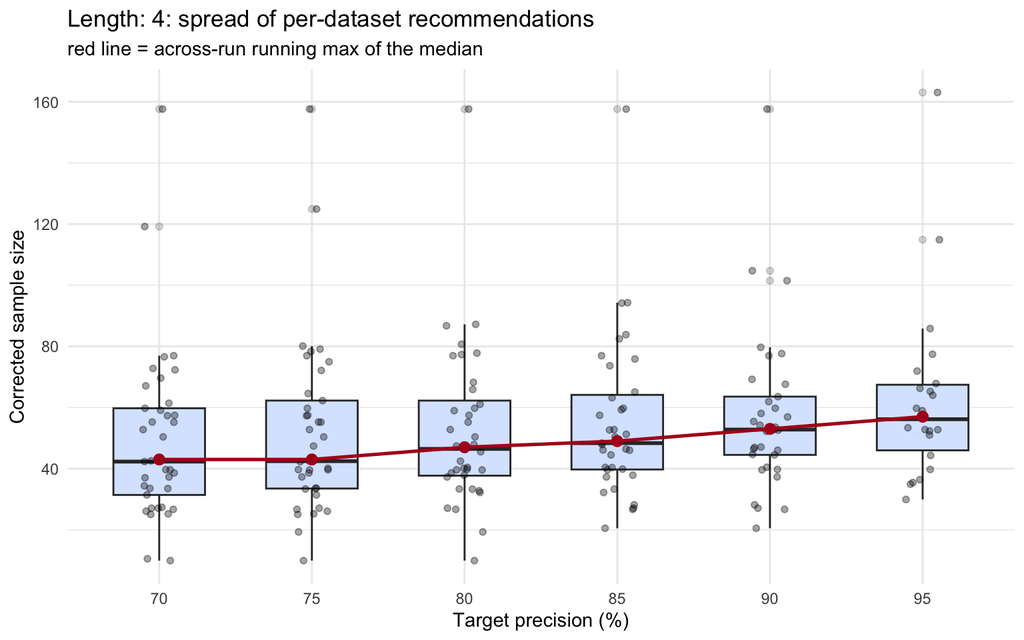

**Reliability by sample size (median across runs):**

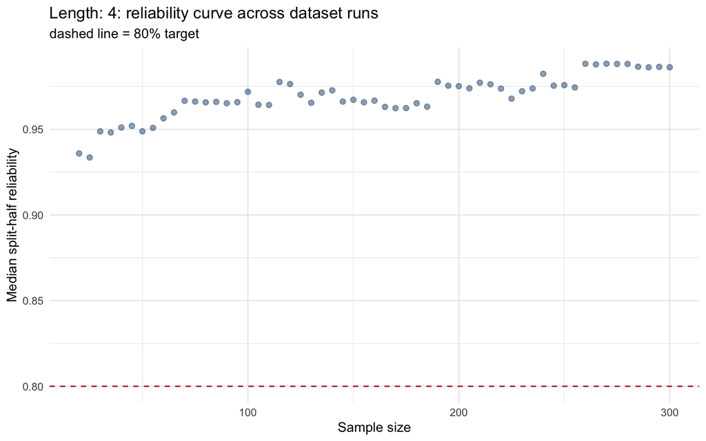

**Recommended n (80% precision + 80% reliability, IQR-trimmed medians averaged): 32.8 -> 33 participants/item**

- Precision: 45.5 (median of 35/36 runs kept after IQR trim)
- Reliability: 20.0 (median of 35/36 runs kept after IQR trim)

**Per-dataset detail (n at target precision, n at target reliability, outlier flags):**

| run_id | n_precision | n_reliability | precision_outlier | reliability_outlier |
| --- | --- | --- | --- | --- |
| janschewitz | 157.6 | 20 | True | False |
| barca | 87.2 | 20 | False | False |
| kraljevic | 86.7 | 20 | False | False |
| raslescu | 80.7 | 20 | False | False |
| desrochers10 | 77.8 | 20 | False | False |
| eilola_finnish | 77.3 | 20 | False | False |
| ballot | 76.9 | 20 | False | False |
| desrochers | 68.2 | 20 | False | False |
| morrow_young | 65.9 | 20 | False | False |
| morrow_old | 61 | 20 | False | False |

[output cut: 27 more lines]

### 5 letters

Based on 36 dataset run(s).

**Recommended sample size per item, by target precision (% of simulations hitting the AIPE cutoff):**

| target_power | n_runs | mean_recommended_sample_size | median_recommended_sample_size | sd_recommended_sample_size | min_recommended_sample_size | max_recommended_sample_size | recommended_sample_size |
| --- | --- | --- | --- | --- | --- | --- | --- |
| 70 | 36 | 48.13 | 46.35 | 26.16 | 9.31 | 158.41 | 47 |
| 75 | 36 | 49.22 | 48.98 | 26.25 | 9.31 | 158.41 | 49 |
| 80 | 36 | 52.09 | 51.74 | 25.87 | 9.88 | 158.41 | 52 |
| 85 | 35 | 56.24 | 56.39 | 26.32 | 19.15 | 158.41 | 57 |
| 90 | 35 | 61.2 | 61.3 | 26.76 | 20.54 | 158.41 | 62 |
| 95 | 28 | 66.69 | 62.9 | 27.92 | 29.9 | 158.41 | 63 |

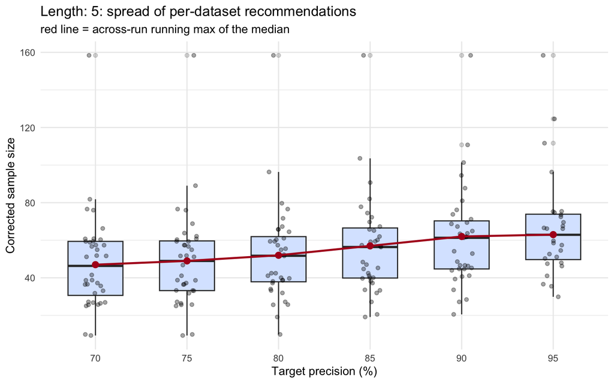

**Reliability by sample size (median across runs):**

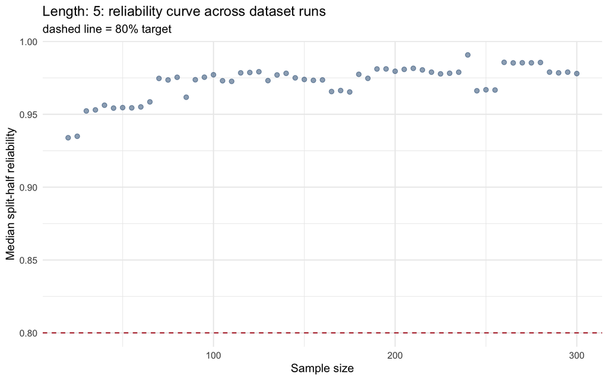

**Recommended n (80% precision + 80% reliability, IQR-trimmed medians averaged): 35.8 -> 36 participants/item**

- Precision: 51.6 (median of 35/36 runs kept after IQR trim)
- Reliability: 20.0 (median of 34/35 runs kept after IQR trim)

**Per-dataset detail (n at target precision, n at target reliability, outlier flags):**

| run_id | n_precision | n_reliability | precision_outlier | reliability_outlier |
| --- | --- | --- | --- | --- |
| janschewitz | 158.4 | 20 | True | False |
| chedid | 96.3 | 20 | False | False |
| barca | 79.7 | 20 | False | False |
| ballot | 76.6 | 20 | False | False |
| desrochers10 | 71.7 | 20 | False | False |
| surprenant | 67.3 | 20 | False | False |
| kraljevic | 65.8 | 20 | False | False |
| morrow_young | 65.8 | 20 | False | False |
| desrochers | 64.5 | 20 | False | False |
| morrow_old | 61.1 | 20 | False | False |

[output cut: 26 more lines]

### 6 letters

Based on 36 dataset run(s).

**Recommended sample size per item, by target precision (% of simulations hitting the AIPE cutoff):**

| target_power | n_runs | mean_recommended_sample_size | median_recommended_sample_size | sd_recommended_sample_size | min_recommended_sample_size | max_recommended_sample_size | recommended_sample_size |
| --- | --- | --- | --- | --- | --- | --- | --- |
| 70 | 36 | 46.66 | 38.16 | 25.98 | 9.33 | 158.34 | 39 |
| 75 | 36 | 48.39 | 40.18 | 26.24 | 9.33 | 158.34 | 41 |
| 80 | 36 | 51.81 | 42.36 | 26.31 | 9.75 | 158.34 | 43 |
| 85 | 36 | 55.61 | 47.84 | 26.74 | 19.33 | 158.34 | 48 |
| 90 | 36 | 60.23 | 52.73 | 27.48 | 20.44 | 158.34 | 53 |
| 95 | 29 | 63.82 | 58.48 | 26.93 | 28.84 | 158.34 | 59 |

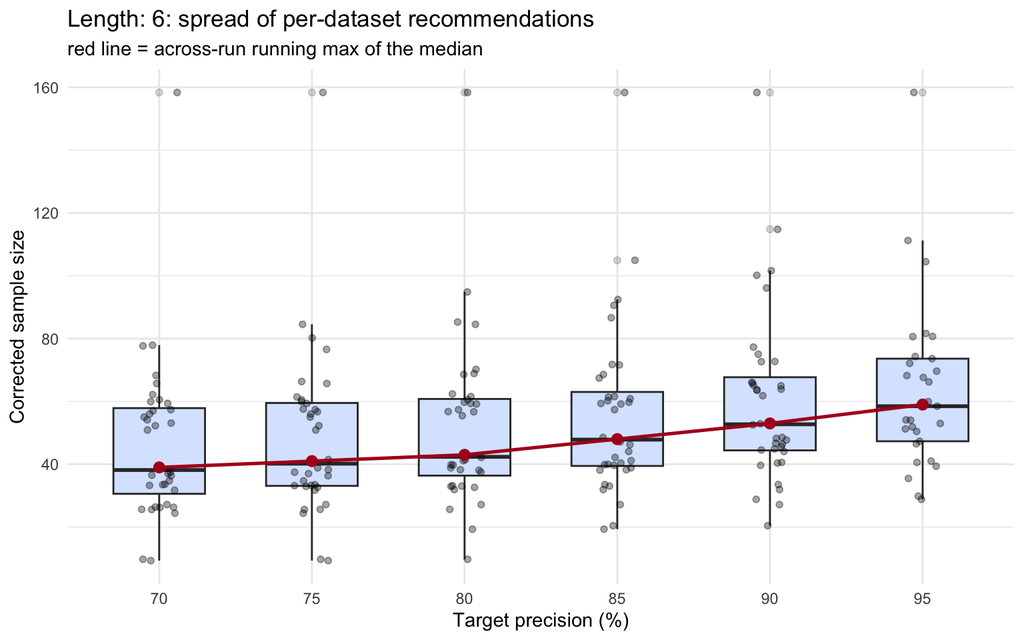

**Reliability by sample size (median across runs):**

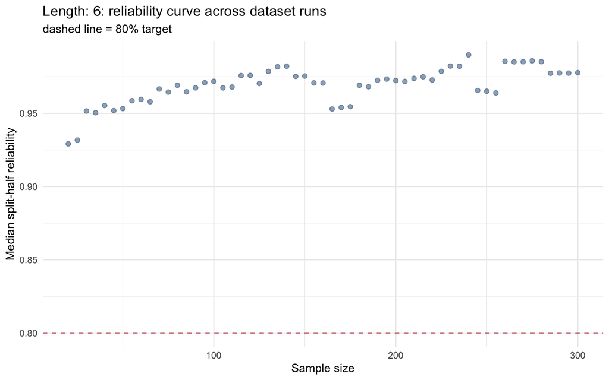

**Recommended n (80% precision + 80% reliability, IQR-trimmed medians averaged): 31.1 -> 32 participants/item**

- Precision: 42.2 (median of 35/36 runs kept after IQR trim)
- Reliability: 20.0 (median of 33/36 runs kept after IQR trim)

**Per-dataset detail (n at target precision, n at target reliability, outlier flags):**

| run_id | n_precision | n_reliability | precision_outlier | reliability_outlier |
| --- | --- | --- | --- | --- |
| janschewitz | 158.3 | 20 | True | False |
| barca | 94.9 | 20 | False | False |
| ballot | 85.3 | 20 | False | False |
| chedid | 84.5 | 20 | False | False |
| kraljevic | 70.2 | 20 | False | False |
| eilola_finnish | 68.9 | 20 | False | False |
| desrochers10 | 68.6 | 20 | False | False |
| raslescu | 62.4 | 20 | False | False |
| morrow_young | 61.5 | 20 | False | False |
| desrochers | 60.5 | 25 | False | True |

[output cut: 26 more lines]

### 7 letters

Based on 37 dataset run(s).

**Recommended sample size per item, by target precision (% of simulations hitting the AIPE cutoff):**

| target_power | n_runs | mean_recommended_sample_size | median_recommended_sample_size | sd_recommended_sample_size | min_recommended_sample_size | max_recommended_sample_size | recommended_sample_size |
| --- | --- | --- | --- | --- | --- | --- | --- |
| 70 | 37 | 46.63 | 38.96 | 25.99 | 8.8 | 157.68 | 39 |
| 75 | 37 | 48.09 | 41.97 | 25.66 | 8.8 | 157.68 | 42 |
| 80 | 37 | 50.42 | 42.35 | 25.84 | 8.8 | 157.68 | 43 |
| 85 | 36 | 53.09 | 47.5 | 25.79 | 19.53 | 157.68 | 48 |
| 90 | 36 | 58.06 | 49.34 | 25.98 | 19.53 | 157.68 | 50 |
| 95 | 30 | 64.85 | 54.18 | 28.74 | 28.98 | 160.42 | 55 |

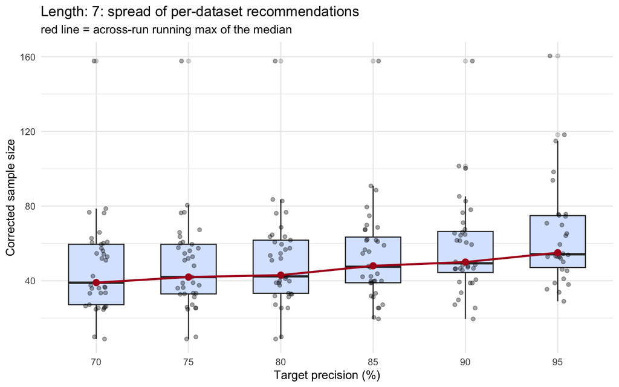

**Reliability by sample size (median across runs):**

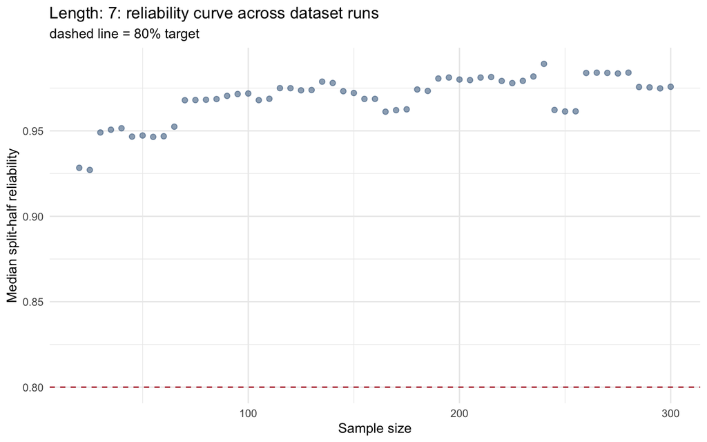

**Recommended n (80% precision + 80% reliability, IQR-trimmed medians averaged): 31.1 -> 32 participants/item**

- Precision: 42.2 (median of 36/37 runs kept after IQR trim)
- Reliability: 20.0 (median of 34/36 runs kept after IQR trim)

**Per-dataset detail (n at target precision, n at target reliability, outlier flags):**

| run_id | n_precision | n_reliability | precision_outlier | reliability_outlier |
| --- | --- | --- | --- | --- |
| janschewitz | 157.7 | 20 | True | False |
| barca | 83.5 | 20 | False | False |
| eilola_finnish | 82.7 | 20 | False | False |
| ballot | 76.7 | 20 | False | False |
| chedid | 76.1 | 20 | False | False |
| desrochers10 | 68.6 | 20 | False | False |
| desrochers | 64.6 | 80 | False | True |
| eilola_english | 63.6 | 20 | False | False |
| surprenant | 63.6 | 20 | False | False |
| morrow_young | 61.7 | 20 | False | False |

[output cut: 27 more lines]

### 8 letters

Based on 35 dataset run(s).

**Recommended sample size per item, by target precision (% of simulations hitting the AIPE cutoff):**

| target_power | n_runs | mean_recommended_sample_size | median_recommended_sample_size | sd_recommended_sample_size | min_recommended_sample_size | max_recommended_sample_size | recommended_sample_size |
| --- | --- | --- | --- | --- | --- | --- | --- |
| 70 | 35 | 45.14 | 37.1 | 25.92 | 9.69 | 158.25 | 38 |
| 75 | 35 | 47.45 | 40.2 | 25.75 | 9.75 | 158.25 | 41 |
| 80 | 35 | 49.77 | 42.02 | 25.98 | 9.75 | 158.25 | 43 |
| 85 | 35 | 53.24 | 46.92 | 26.47 | 9.75 | 158.25 | 47 |
| 90 | 35 | 58.24 | 52.79 | 26.46 | 20.55 | 158.25 | 53 |
| 95 | 30 | 62.9 | 57.88 | 26.25 | 29.92 | 158.25 | 58 |

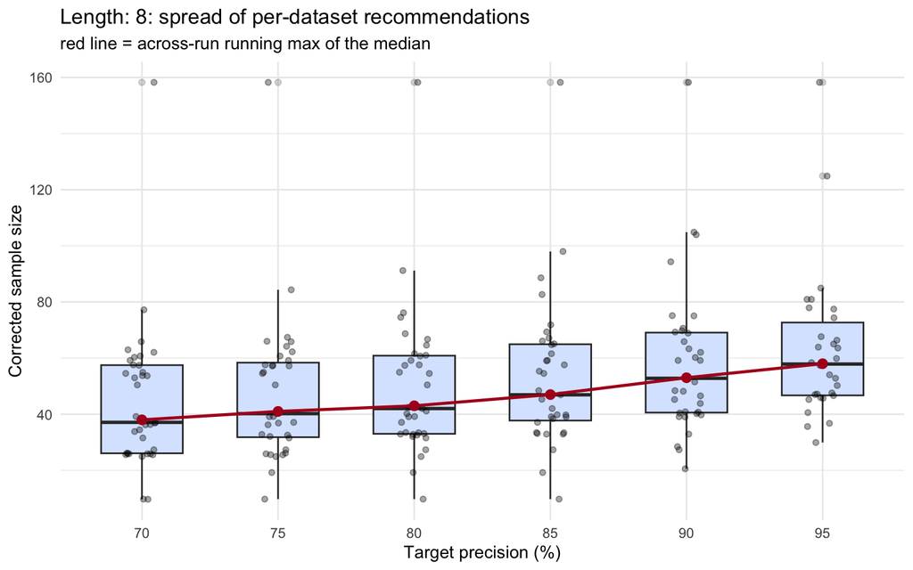

**Reliability by sample size (median across runs):**

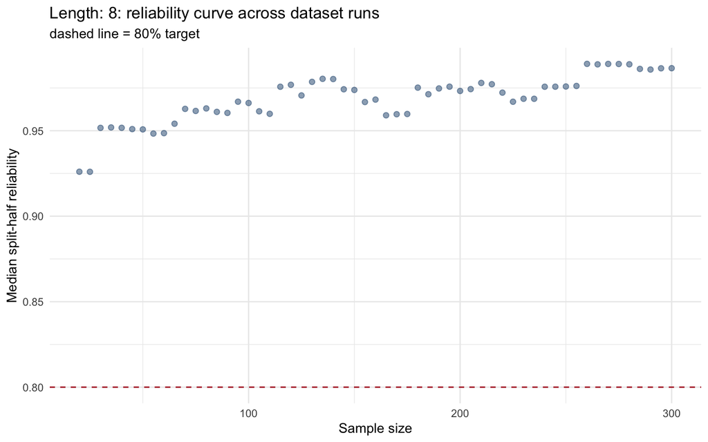

**Recommended n (80% precision + 80% reliability, IQR-trimmed medians averaged): 30.8 -> 31 participants/item**

- Precision: 41.6 (median of 34/35 runs kept after IQR trim)
- Reliability: 20.0 (median of 32/34 runs kept after IQR trim)

**Per-dataset detail (n at target precision, n at target reliability, outlier flags):**

| run_id | n_precision | n_reliability | precision_outlier | reliability_outlier |
| --- | --- | --- | --- | --- |
| janschewitz | 158.2 | 20 | True | False |
| barca | 91.2 | 20 | False | False |
| chedid | 76.1 | 20 | False | False |
| kraljevic | 74.5 | 20 | False | False |
| desrochers10 | 68.7 | 20 | False | False |
| eilola_finnish | 66.7 | 20 | False | False |
| raslescu | 64.6 | 20 | False | False |
| zechmeister | 61.6 | 20 | False | False |
| morrow_old | 61 | 20 | False | False |
| desrochers | 60.7 | 80 | False | True |

[output cut: 25 more lines]

### 9 letters

Based on 32 dataset run(s).

**Recommended sample size per item, by target precision (% of simulations hitting the AIPE cutoff):**

| target_power | n_runs | mean_recommended_sample_size | median_recommended_sample_size | sd_recommended_sample_size | min_recommended_sample_size | max_recommended_sample_size | recommended_sample_size |
| --- | --- | --- | --- | --- | --- | --- | --- |
| 70 | 32 | 44.92 | 38.51 | 26.93 | 8.85 | 158.15 | 39 |
| 75 | 32 | 46.27 | 40.67 | 26.93 | 8.85 | 158.15 | 41 |
| 80 | 32 | 48.09 | 41.76 | 27.48 | 8.85 | 158.15 | 42 |
| 85 | 32 | 52.49 | 46.78 | 27.46 | 9.74 | 158.15 | 47 |
| 90 | 31 | 54.94 | 47.4 | 28.17 | 19.42 | 158.15 | 48 |
| 95 | 26 | 56.59 | 52.4 | 25.36 | 28.93 | 158.15 | 53 |

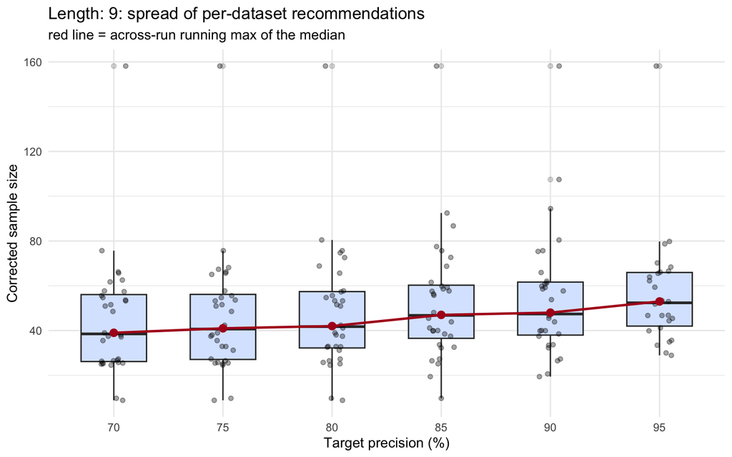

**Reliability by sample size (median across runs):**

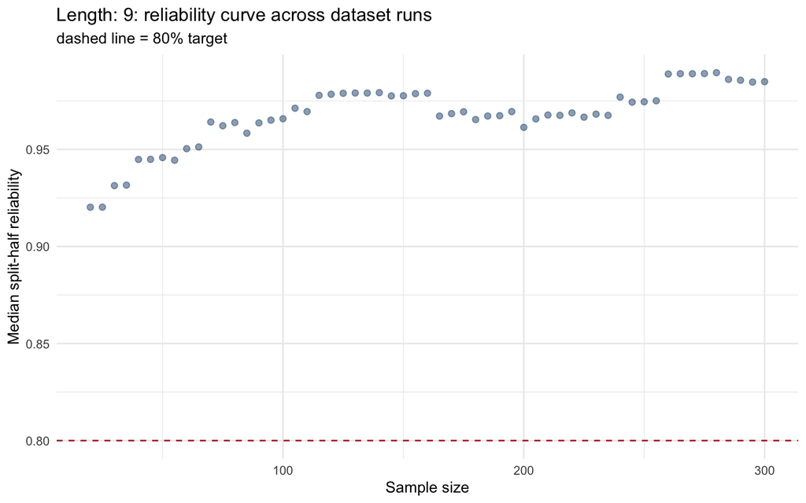

**Recommended n (80% precision + 80% reliability, IQR-trimmed medians averaged): 30.6 -> 31 participants/item**

- Precision: 41.2 (median of 31/32 runs kept after IQR trim)
- Reliability: 20.0 (median of 29/32 runs kept after IQR trim)

**Per-dataset detail (n at target precision, n at target reliability, outlier flags):**

| run_id | n_precision | n_reliability | precision_outlier | reliability_outlier |
| --- | --- | --- | --- | --- |
| janschewitz | 158.2 | 20 | True | False |
| chedid | 80.5 | 20 | False | False |
| barca | 75.7 | 20 | False | False |
| kraljevic | 74.7 | 20 | False | False |
| raslescu | 72.6 | 20 | False | False |
| desrochers | 68.8 | 80 | False | True |
| desrochers10 | 65.6 | 20 | False | False |
| sianipar | 57.7 | 80 | False | True |
| morrow_old | 57.3 | 20 | False | False |
| surprenant | 55.6 | 20 | False | False |

[output cut: 22 more lines]

### 10 letters

Based on 29 dataset run(s).

**Recommended sample size per item, by target precision (% of simulations hitting the AIPE cutoff):**

| target_power | n_runs | mean_recommended_sample_size | median_recommended_sample_size | sd_recommended_sample_size | min_recommended_sample_size | max_recommended_sample_size | recommended_sample_size |
| --- | --- | --- | --- | --- | --- | --- | --- |
| 70 | 29 | 38.9 | 35.69 | 16.46 | 9.36 | 65.03 | 36 |
| 75 | 29 | 40.04 | 37.24 | 16.08 | 9.36 | 65.03 | 38 |
| 80 | 29 | 42.07 | 38.69 | 15.72 | 9.85 | 66.83 | 39 |
| 85 | 29 | 45.56 | 41.89 | 16.12 | 19.19 | 84.61 | 42 |
| 90 | 29 | 49.84 | 45.23 | 17.08 | 27.54 | 96.59 | 46 |
| 95 | 27 | 57.71 | 51.58 | 19.86 | 28.65 | 111.47 | 52 |

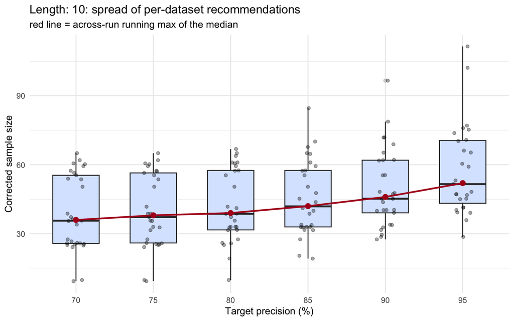

**Reliability by sample size (median across runs):**

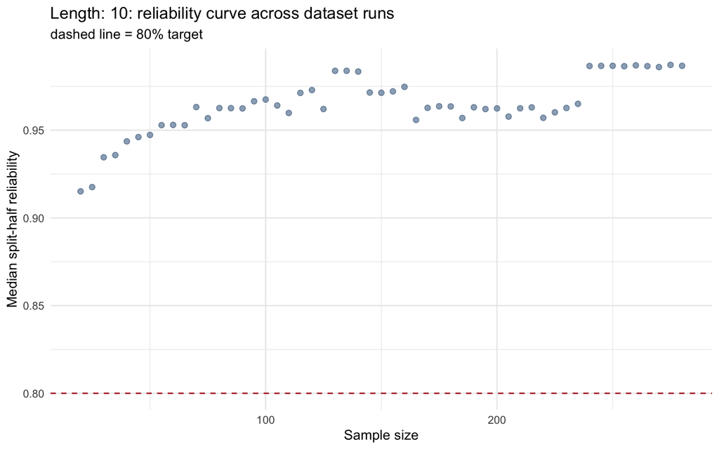

**Recommended n (80% precision + 80% reliability, IQR-trimmed medians averaged): 29.3 -> 30 participants/item**

- Precision: 38.7 (median of 29/29 runs kept after IQR trim)
- Reliability: 20.0 (median of 26/28 runs kept after IQR trim)

**Per-dataset detail (n at target precision, n at target reliability, outlier flags):**

| run_id | n_precision | n_reliability | precision_outlier | reliability_outlier |
| --- | --- | --- | --- | --- |
| chedid | 66.8 | 20 | False | False |
| desrochers10 | 65 | 20 | False | False |
| surprenant | 63.8 | 20 | False | False |
| kraljevic | 61 | 20 | False | False |
| morrow_old | 61 | 20 | False | False |
| desrochers | 60.6 | 80 | False | True |
| raslescu | 59.4 | 20 | False | False |
| morrow_young | 57.5 | 20 | False | False |
| sianipar | 57.4 | 80 | False | True |
| mahjou | 55.4 | 20 | False | False |

[output cut: 19 more lines]

### 11+ letters

Based on 30 dataset run(s).

**Recommended sample size per item, by target precision (% of simulations hitting the AIPE cutoff):**

| target_power | n_runs | mean_recommended_sample_size | median_recommended_sample_size | sd_recommended_sample_size | min_recommended_sample_size | max_recommended_sample_size | recommended_sample_size |
| --- | --- | --- | --- | --- | --- | --- | --- |
| 70 | 30 | 40.33 | 37.68 | 16.85 | 9.2 | 68.2 | 38 |
| 75 | 30 | 41.1 | 38.5 | 17.22 | 9.2 | 69.87 | 39 |
| 80 | 30 | 42.53 | 38.7 | 17.65 | 9.7 | 72.05 | 39 |
| 85 | 30 | 47 | 42.09 | 18.1 | 9.7 | 75.96 | 43 |
| 90 | 30 | 50.43 | 46.04 | 19.85 | 19.24 | 92.76 | 47 |
| 95 | 29 | 55.92 | 51.71 | 20.95 | 20.8 | 111.55 | 52 |

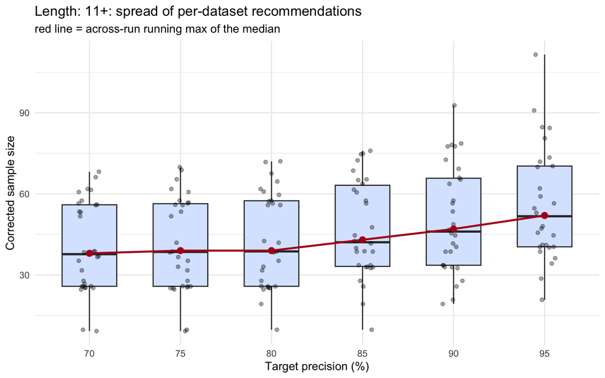

**Reliability by sample size (median across runs):**

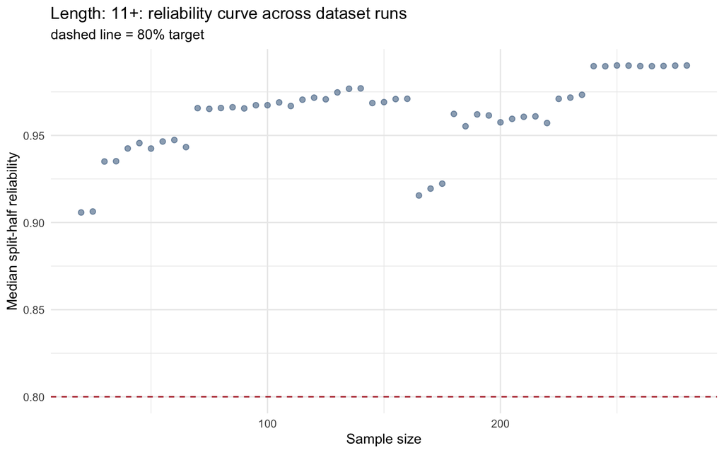

**Recommended n (80% precision + 80% reliability, IQR-trimmed medians averaged): 29.4 -> 30 participants/item**

- Precision: 38.7 (median of 30/30 runs kept after IQR trim)
- Reliability: 20.0 (median of 26/29 runs kept after IQR trim)

**Per-dataset detail (n at target precision, n at target reliability, outlier flags):**

| run_id | n_precision | n_reliability | precision_outlier | reliability_outlier |
| --- | --- | --- | --- | --- |
| eilola_finnish | 72.1 | 20 | False | False |
| desrochers10 | 71.8 | 20 | False | False |
| raslescu | 67.5 | 20 | False | False |
| desrochers | 64.6 | 80 | False | True |
| chedid | 61.8 | 20 | False | False |
| morrow_old | 60.9 | 20 | False | False |
| surprenant | 59.6 | 20 | False | False |
| sianipar | 57.5 | 80 | False | True |
| morrow_young | 57.3 | 20 | False | False |
| mahjou | 56.5 | 20 | False | False |

[output cut: 20 more lines]

## Comparison Across Subgroups

The POS and word-length breakdowns above are exploratory: they show whether any lexical class needs a *different* number of raters than the study as a whole, not a number to combine with the overall estimate. The chart below compares each subgroup’s recommended n against the overall recommendation.

```r
comparison_tbl <- dplyr::bind_rows(
  tibble::tibble(category = "Overall", group = "Overall", recommended_n = overall_rec$recommended_n),
  purrr::imap_dfr(pos_rec_by_group, ~ tibble::tibble(category = "POS", group = .y, recommended_n = .x$recommended_n)),
  purrr::imap_dfr(length_rec_by_group, ~ tibble::tibble(category = "Length", group = .y, recommended_n = .x$recommended_n))
) %>%
  dplyr::mutate(recommended_n = round(recommended_n, 1))

DT::datatable(comparison_tbl, rownames = FALSE, options = list(dom = "t", pageLength = 20))
```

| category | group | recommended_n |
| --- | --- | --- |
| Overall | Overall | 31.1 |
| POS | modifiers | 32.7 |
| POS | noun | 31.1 |
| POS | other | 28.5 |
| POS | verb | 29.9 |
| Length | 3 | 38.5 |
| Length | 4 | 32.8 |
| Length | 5 | 35.8 |
| Length | 6 | 31.1 |
| Length | 7 | 31.1 |

[output cut: 4 more lines]

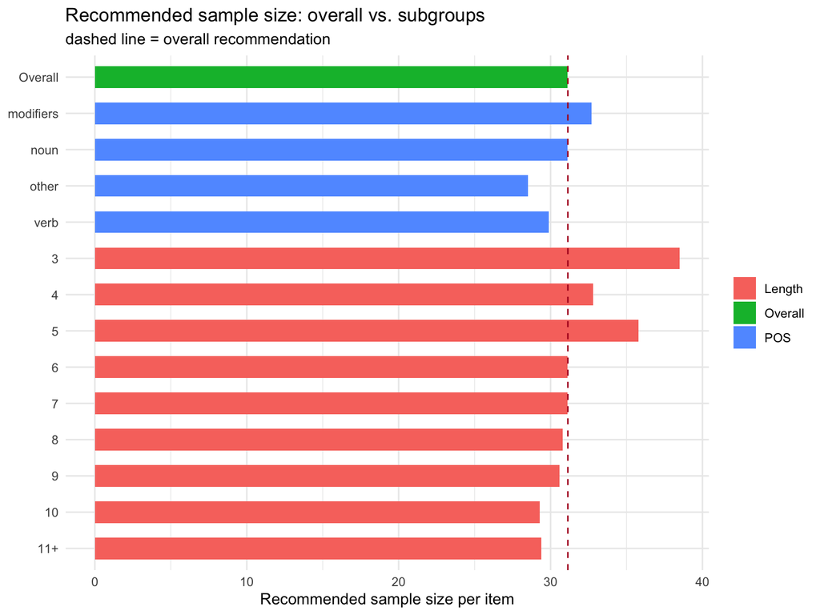

```r
comparison_tbl %>%
  dplyr::mutate(group = factor(group, levels = rev(c("Overall", pos_groups, length_groups)))) %>%
  ggplot2::ggplot(ggplot2::aes(x = group, y = recommended_n, fill = category)) +
  ggplot2::geom_col(width = 0.6) +
  ggplot2::geom_hline(yintercept = overall_rec$recommended_n, linetype = "dashed", color = "#b00020") +
  ggplot2::coord_flip() +
  ggplot2::labs(
    x = NULL, y = "Recommended sample size per item", fill = NULL,
    title = "Recommended sample size: overall vs. subgroups",
    subtitle = "dashed line = overall recommendation"
  ) +
  ggplot2::theme_minimal()
```

The plot below overlays every subgroup’s precision curve (recommended sample size at each target precision level, 70/75/80/85/90/95%) on two panels - all POS tags on the left, all word-length buckets on the right - so subgroups within each category can be compared directly against each other, with the overall curve repeated as a dashed grey reference in both panels. If POS and word length don’t matter much for sample size planning, the colored curves should stay tightly bunched around their dashed reference.

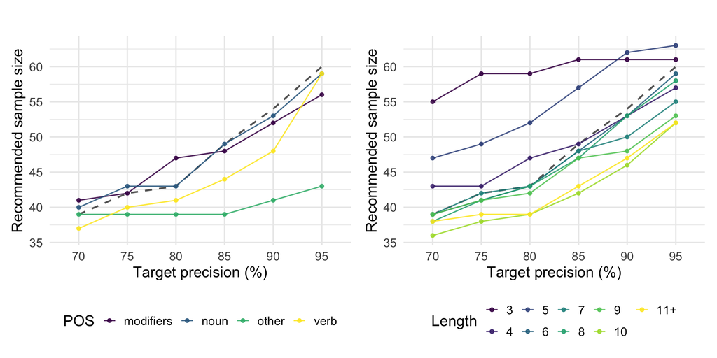

```r
library(patchwork)

overall_curve <- summarize_by_target(refined_summary$overall_power) %>%
  dplyr::mutate(target_power = factor(target_power, levels = REFINE_POWER_LEVELS))

pos_curves <- purrr::map_dfr(pos_groups, function(g) {
  summarize_by_target(refined_summary$pos_power %>% dplyr::filter(group == g)) %>%
    dplyr::mutate(group = g)
}) %>%
  dplyr::mutate(
    target_power = factor(target_power, levels = REFINE_POWER_LEVELS),
    group = factor(group, levels = pos_groups)
  )

length_curves <- purrr::map_dfr(length_groups, function(g) {
  summarize_by_target(refined_summary$length_power %>% dplyr::filter(group == g)) %>%
    dplyr::mutate(group = g)
}) %>%
  dplyr::mutate(
    target_power = factor(target_power, levels = REFINE_POWER_LEVELS),
    group = factor(group, levels = length_groups)
  )

shared_y <- range(c(overall_curve$recommended_sample_size,
                     pos_curves$recommended_sample_size,
                     length_curves$recommended_sample_size), na.rm = TRUE)

subgroup_curve_plot <- function(dat, title, legend_title) {
  ggplot2::ggplot(dat, ggplot2::aes(x = target_power, y = recommended_sample_size, group = group)) +
    ggplot2::geom_line(
      data = overall_curve,
      ggplot2::aes(x = target_power, y = recommended_sample_size, group = 1),
      inherit.aes = FALSE,
      color = "grey40", linetype = "dashed", linewidth = 1
    ) +
    ggplot2::geom_line(ggplot2::aes(color = group), linewidth = 0.7, alpha = 0.85) +
    ggplot2::geom_point(ggplot2::aes(color = group), size = 1.6, alpha = 0.85) +
    ggplot2::scale_color_viridis_d(option = "D") +
    ggplot2::scale_y_continuous(limits = shared_y) +
    ggplot2::labs(
      x = "Target precision (%)", y = "Recommended sample size",
      title = title, color = legend_title
    ) +
    ggplot2::theme_minimal(base_size = 18) +
    ggplot2::theme(legend.position = "bottom")
}

pos_plot <- subgroup_curve_plot(pos_curves, " ", "POS")
length_plot <- subgroup_curve_plot(length_curves, " ", "Length")

(pos_plot | length_plot)
```

```r
#+
#  patchwork::plot_annotation(
#    title = "Subgroup precision curves vs. the overall recommendation",
#    subtitle = "Dashed grey = overall curve (repeated in every panel for reference); POS on the left, word length on the right"
#  )

ggsave(
  filename = "comparison_aipe_rel.png",
  dpi = 300
)
```

```r
subgroup_max <- comparison_tbl %>%
  dplyr::filter(category != "Overall") %>%
  dplyr::filter(recommended_n == max(recommended_n, na.rm = TRUE))

cat(sprintf(
  "Bottom line: averaging %d%% precision and %d%% reliability (after dropping outlier dataset runs via the 1.5 x IQR rule) puts the overall recommended sample size at **%d participants per item**. The most demanding subgroup is %s (%s), at %.1f participants/item; every other subgroup falls at or below that.\n",
  TARGET_POWER, TARGET_RELIABILITY * 100, ceiling(overall_rec$recommended_n),
  subgroup_max$group[[1]], subgroup_max$category[[1]], subgroup_max$recommended_n[[1]]
))
```

Bottom line: averaging 80% precision and 80% reliability (after dropping outlier dataset runs via the 1.5 x IQR rule) puts the overall recommended sample size at **32 participants per item**. The most demanding subgroup is 3 (Length), at 38.5 participants/item; every other subgroup falls at or below that.